# Karriereerwartung PCA

## Reliability

We will delve into the scale for our most important variable: `Karriereerwartung`. This variable is used as independent variable in most of our hypotheses. It indicates the aspiration for a good career development after completion of studies. We measured this latent variable using the following five Likert items with five levels each:

- `Fachliche Weiterentwicklung`
- `Eine Stelle im Fachgebiet`
- `Einkommen`
- `Ansehen des Unternehmens`
- `Aufstiegsmöglichkeiten`

Let’s measure the reliability of these items using Cronbach’s alpha. First, we need to load the data.

```r
library(psych)
data <- read.csv('survey_696322_R_data_file.csv')
data <- data[,2:6]
var.names <- c('Fachliche Weiterentwicklung', 'Eine Stelle im Fachgebiet', 'Einkommen', 'Ansehen des Unternehmens', 'Aufstiegsmöglichkeiten')
```

To calculate Cronbach’s alpha, we need to convert the categorical variables into their numerical representation.

```r
indx <- sapply(data, is.factor)
data[indx] <- lapply(data[indx], as.numeric)
```

Now we can calculate Cronbach’s alpha.

```r
alpha(data)
```

```
##
## Reliability analysis
## Call: alpha(x = data)
##
##   raw_alpha std.alpha G6(smc) average_r S/N   ase mean   sd median_r
##       0.51      0.53    0.58      0.19 1.1 0.077  2.2 0.51     0.18
##
##  lower alpha upper     95% confidence boundaries
## 0.36 0.51 0.66
##
##  Reliability if an item is dropped:
##             raw_alpha std.alpha G6(smc) average_r  S/N alpha se var.r
## Q001.SQ001.      0.43      0.44    0.49      0.16 0.77    0.093 0.052
## Q001.SQ002.      0.45      0.49    0.49      0.19 0.96    0.089 0.029
## Q001.SQ003.      0.49      0.52    0.49      0.21 1.08    0.081 0.024
## Q001.SQ004.      0.46      0.48    0.52      0.19 0.91    0.092 0.058
## Q001.SQ005.      0.46      0.46    0.46      0.17 0.84    0.082 0.040
##             med.r
## Q001.SQ001.  0.12
## Q001.SQ002.  0.18
## Q001.SQ003.  0.21
## Q001.SQ004.  0.14
## Q001.SQ005.  0.18
##
##  Item statistics
##               n raw.r std.r r.cor r.drop mean   sd
## Q001.SQ001. 100  0.57  0.64  0.49   0.36  1.6 0.64
## Q001.SQ002. 100  0.59  0.57  0.44   0.29  2.1 0.89
## Q001.SQ003. 100  0.51  0.54  0.40   0.23  1.8 0.77
## Q001.SQ004. 100  0.69  0.59  0.41   0.31  3.7 1.16
## Q001.SQ005. 100  0.56  0.61  0.50   0.28  1.7 0.80
##
## Non missing response frequency for each item
##                1    2    3    4    5 miss
## Q001.SQ001. 0.49 0.45 0.05 0.01 0.00    0
## Q001.SQ002. 0.27 0.42 0.24 0.07 0.00    0
## Q001.SQ003. 0.36 0.51 0.10 0.02 0.01    0
## Q001.SQ004. 0.04 0.12 0.25 0.26 0.33    0
## Q001.SQ005. 0.46 0.43 0.06 0.05 0.00    0
```

Cronbach’s alpha is 0.51. This value is relatively low and shows that our items do not measure the same latent variable. This means that the reliability of our measurement is not good. A Cronbach’s alpha greater than 0,6 would be preferable.

## Principal component analysis

It seems as though our scale does not measure what we want it to measure. It could be the case that there are acutally more latent variables underlying our items. To investigate this, we will employ a Principal component analysis (PCA). A PCA attempts to construct components (or factors) as linear combination of items s.t. they are orthogonal to each other and capture the variance of the sample.

Before we begin our PCA, let’s use the KMO to measure the suitability of our data to a PCA.

```r
KMO(data)
```

```
## Kaiser-Meyer-Olkin factor adequacy
## Call: KMO(r = data)
## Overall MSA =  0.49
## MSA for each item =
## Q001.SQ001. Q001.SQ002. Q001.SQ003. Q001.SQ004. Q001.SQ005.
##        0.60        0.50        0.42        0.47        0.47
```

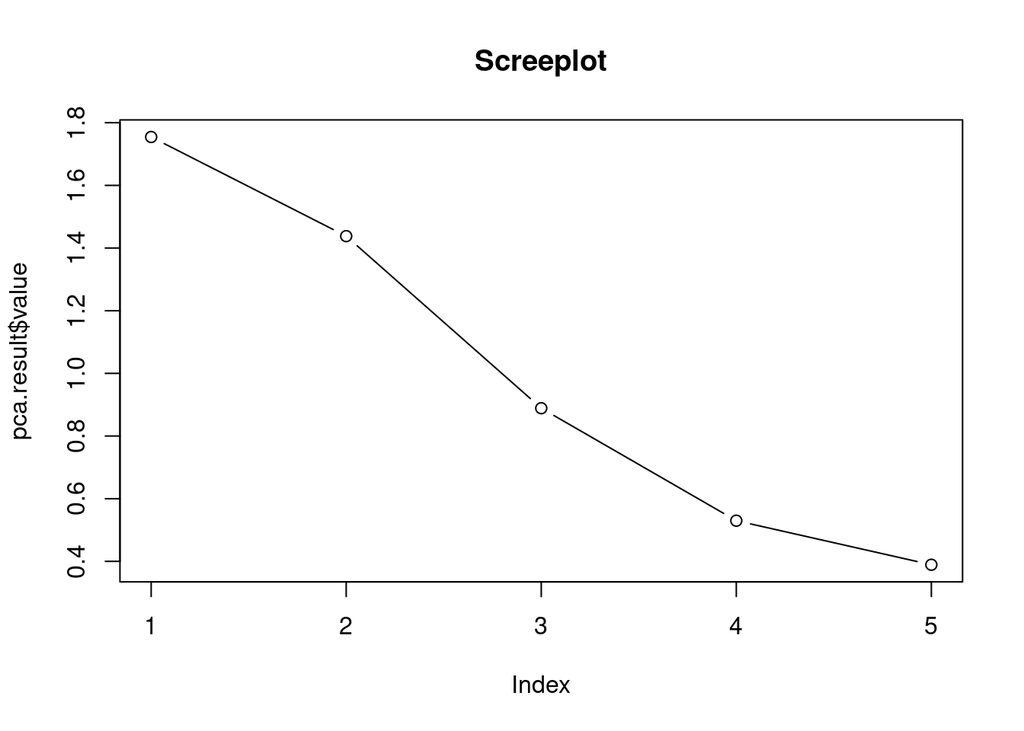

```r
pca.result <- principal(data, nfactors = 2, scores = TRUE)
plot(pca.result$value, type = 'b', main = 'Screeplot')
```

The result of a PCA can be visualized using a scree plot. This plot indicates the captured variance for each of the constructed factors. As a visual intuition, all factors prior to the “ellbow” in the plot are eligible factors. Our plot shows an elbow at the third factor, therefore we need two factors to explain the variance in our data.

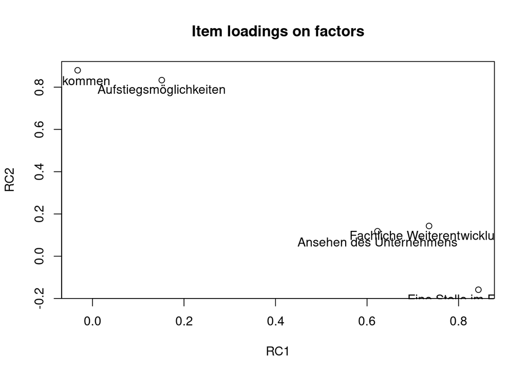

```r
plot(pca.result$loadings, main = "Item loadings on factors")
text(pca.result$loadings[,1], pca.result$loadings[,2] - 0.05, var.names)
```

As each factor $f$ is a linear combination of our original items $f=\sum_{i=0}^N \alpha_i l_i$ (where $l_i$ is the $i$th item), the loading $\alpha_i$ shows the importance of the item $l_i$.

The loading plot above uses this information to show the item loadings on both factors.

```r
factored_data <- as.matrix(predict(pca.result, data))
colnames(factored_data) <- c("Entwicklung", "Erfolg")
alpha(factored_data)
```

```
##
## Reliability analysis
## Call: alpha(x = factored_data)
##
##   raw_alpha std.alpha  G6(smc) average_r      S/N ase     mean   sd
##   -4.4e-16  -8.9e-16 -4.4e-16  -3.3e-16 -6.7e-16 0.2 -3.7e-17 0.71
##  median_r
##  -3.4e-16
##
##  lower alpha upper     95% confidence boundaries
## -0.39 0 0.39
##
##  Reliability if an item is dropped:
##             raw_alpha std.alpha G6(smc) average_r S/N alpha se    var.r
## Entwicklung  -3.4e-16  -3.4e-16       0  -3.4e-16  NA       NA -3.4e-16
## Erfolg        0.0e+00  -3.4e-16      NA        NA  NA       NA  0.0e+00
##                med.r
## Entwicklung -3.4e-16
## Erfolg      -3.4e-16
##
##  Item statistics
##               n raw.r std.r r.cor   r.drop     mean sd
## Entwicklung 100  0.71  0.71   NaN -3.3e-16 -1.4e-17  1
## Erfolg      100  0.71  0.71   NaN -4.4e-16 -5.5e-17  1
```

We decide to denote first factor as `Entwicklung` and second as `Erfolg`.

We transform the dataset from holding the items into holding the factors for each observation.

```r
entwicklung <- data[c(1,2,4)]
alpha(entwicklung)
```

```
##
## Reliability analysis
## Call: alpha(x = entwicklung)
##
##   raw_alpha std.alpha G6(smc) average_r S/N   ase mean   sd median_r
##       0.55      0.58     0.5      0.32 1.4 0.074  2.5 0.67     0.34
##
##  lower alpha upper     95% confidence boundaries
## 0.4 0.55 0.69
##
##  Reliability if an item is dropped:
##             raw_alpha std.alpha G6(smc) average_r  S/N alpha se var.r
## Q001.SQ001.      0.50      0.51    0.34      0.34 1.05    0.096    NA
## Q001.SQ002.      0.28      0.32    0.19      0.19 0.48    0.121    NA
## Q001.SQ004.      0.57      0.59    0.42      0.42 1.46    0.080    NA
##             med.r
## Q001.SQ001.  0.34
## Q001.SQ002.  0.19
## Q001.SQ004.  0.42
##
##  Item statistics
##               n raw.r std.r r.cor r.drop mean   sd
## Q001.SQ001. 100  0.62  0.73  0.51   0.35  1.6 0.64
## Q001.SQ002. 100  0.78  0.80  0.65   0.47  2.1 0.89
## Q001.SQ004. 100  0.79  0.69  0.42   0.33  3.7 1.16
##
## Non missing response frequency for each item
##                1    2    3    4    5 miss
## Q001.SQ001. 0.49 0.45 0.05 0.01 0.00    0
## Q001.SQ002. 0.27 0.42 0.24 0.07 0.00    0
## Q001.SQ004. 0.04 0.12 0.25 0.26 0.33    0
```

`Fachliche Weiterentwicklung`, `Eine Stelle im Fachgebiet` and `Ansehen des Unternehmens` load high, ie greater than 0.4 onto `Entwicklung`. Our Cronbach’s alpha using only those items is 0.55, which is still not good.

```r
erfolg <- data[c(3,5)]
alpha(erfolg)
```

```
##
## Reliability analysis
## Call: alpha(x = erfolg)
##
##   raw_alpha std.alpha G6(smc) average_r S/N   ase mean   sd median_r
##       0.66      0.66     0.5       0.5   2 0.067  1.8 0.68      0.5
##
##  lower alpha upper     95% confidence boundaries
## 0.53 0.66 0.79
##
##  Reliability if an item is dropped:
##             raw_alpha std.alpha G6(smc) average_r S/N alpha se var.r med.r
## Q001.SQ003.      0.50       0.5    0.25       0.5  NA       NA  0.50   0.5
## Q001.SQ005.      0.25       0.5      NA        NA  NA       NA  0.25   0.5
##
##  Item statistics
##               n raw.r std.r r.cor r.drop mean   sd
## Q001.SQ003. 100  0.86  0.86  0.61    0.5  1.8 0.77
## Q001.SQ005. 100  0.87  0.86  0.61    0.5  1.7 0.80
##
## Non missing response frequency for each item
##                1    2    3    4    5 miss
## Q001.SQ003. 0.36 0.51 0.10 0.02 0.01    0
## Q001.SQ005. 0.46 0.43 0.06 0.05 0.00    0
```

`Einkommen` and `Aufstiegsmöglichkeiten` load high, ie greater than 0.4 onto `Erfolg`. Our Cronbach’s alpha using only those items is 0.66.

The factor `Erfolg` is more reliable than `Entwicklung`. Therefore, we decide to discard the factor `Entwicklung` and use only `Erfolg` for future calculations.

What this means for our research is that we do not measure the aspiration for career development of students anymore, but only the aspiration of career success. In other words, we decide to only focus on the “hard” indicators income and position and discard the “soft” ones.

## Factor scores

The `Erfolg` factor can be condensed into a metric variable for each observation. Smaller `Erfolg` scores indicate a lower aspiration for career success.

Let’s look at the `Erfolg` factor scores.

```r
data <- read.csv('survey_696322_R_data_file.csv')
erfolg.scores <- pca.result$scores[,'RC2']
erfolg.scores
```

```
##   [1]  0.44689638 -0.41485826 -1.00406151 -0.09625280  4.14786926
##   [6] -1.09315669  0.32751273  0.21751837  0.96914638 -1.15497638
##  [11] -0.42424755 -1.31102482  0.37356681  1.12532708  0.32751273
##  [16] -1.19164117  1.03609963  0.53599157 -0.96739672 -0.43988090
##  [21] -1.32679043 -0.96739672 -1.13921077 -1.04072630  0.23841754
##  [26]  1.81288255 -0.25230124 -0.37819347 -0.09625280  0.25418315
##  [31] -0.36242786  0.37356681  0.37356681 -1.01982712  1.14096043
##  [36]  1.12532708 -0.25230124  0.61884269  0.49932678 -0.89406715
##  [41] -1.09315669 -1.06588120 -0.32576307 -0.55000752  1.29714113
##  [46]  0.96914638  2.47253467  1.16199187  0.29084794 -1.38435440
##  [51]  3.05248089  1.19865665 -0.17897166 -0.31412092  1.21442226
##  [56]  1.00594343 -0.42424755 -0.37819347 -0.96739672 -1.10254598
##  [61] -0.89406715 -1.17587556  0.27508233  0.41023159  0.91671598
##  [66]  0.41023159  0.23841754 -1.15497638 -0.31412092  1.03623189
##  [71] -0.52259976 -0.23140206 -1.40950930 -0.40321611 -1.32679043
##  [76] -1.17587556 -0.40321611  0.91671598 -0.31412092  0.33690202
##  [81] -0.31412092 -0.96739672 -0.89406715  0.06660349 -1.40950930
##  [86] -0.32049724  0.23841754 -0.13291758  0.41023159  2.03951211
##  [91] -0.48593497  0.41023159 -0.48593497 -1.07225752  0.23841754
##  [96]  0.44689638  0.61871043  0.06660349  0.46266199  0.87354261
```

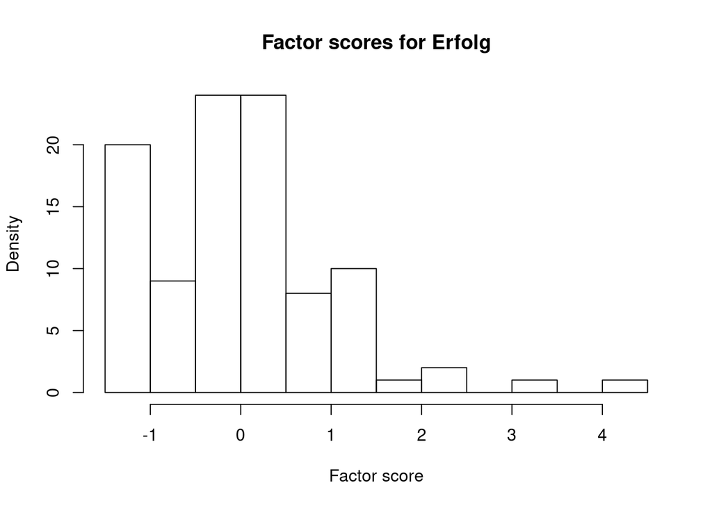

```r
hist(erfolg.scores, xlab = 'Factor score', ylab = 'Density', main = 'Factor scores for Erfolg')
```

We visualize the `Erfolg` factor score distribution using a histogram with fixed bin width. The distribution is skewed right and bimodal.

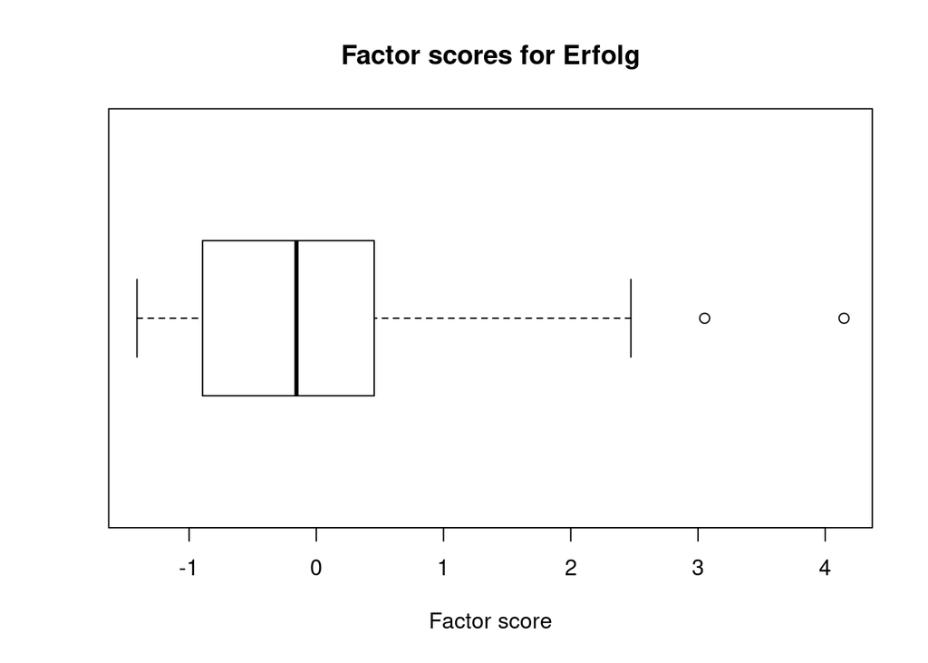

```r
boxplot(erfolg.scores, horizontal = T, xlab = 'Factor score', main = 'Factor scores for Erfolg')
```

The boxplot shows similar indications. We also clearly see two outliers, which might be corrupted data.

```r
summary(erfolg.scores)
```

```
##    Min. 1st Qu.  Median    Mean 3rd Qu.    Max.
## -1.4095 -0.8941 -0.1559  0.0000  0.4508  4.1479
```

This table describes our distribution numerically. The maximum value is likely an outlier.

## Research question

Our research question is: Does the amount of semesters studied impact the aspiration for carrier success? Let’s try to solve this question visually first.

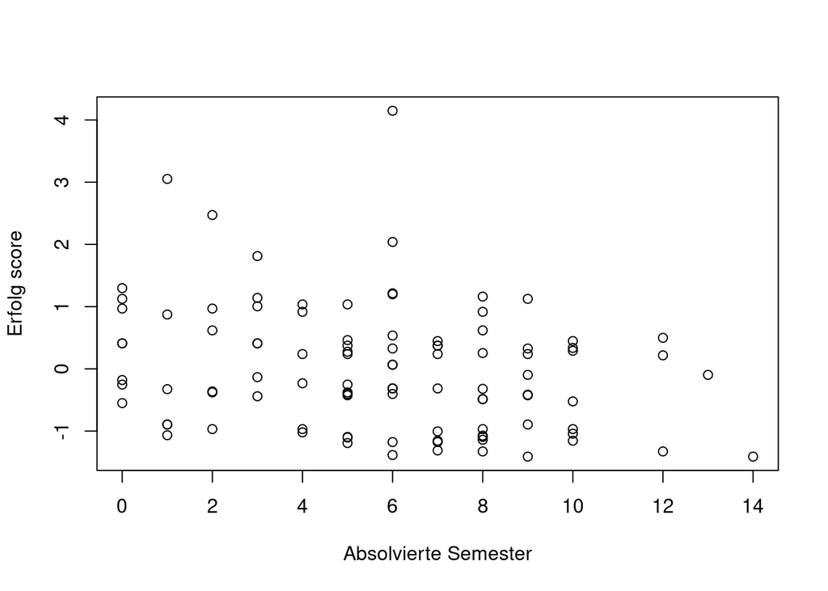

```r
plot(data$Q015, erfolg.scores, xlab = 'Absolvierte Semester', ylab='Erfolg score')
```

The scatter plot shows a slight indication of a correlation of the `Absolvierte Semester` and `Erfolg` variables in our dataset. Now, we will use a correlation test to see if our visual intuition holds up. We decide to use the Pearson as well as the Spearmen correlation test using the following hypotheses:

- $H_0$: The correlation coefficient between `Absolviere Semester` and `Erfolg` is 0.
- $H_A$: The correlation coefficient between `Absolviere Semester` and `Erfolg` is not 0.

```r
cor.test(erfolg.scores, data$Q015, alternative = "two.sided", conf.level = 0.95, method = 'pearson')
```

```
##
##  Pearson's product-moment correlation
##
## data:  erfolg.scores and data$Q015
## t = -2.6475, df = 98, p-value = 0.00945
## alternative hypothesis: true correlation is not equal to 0
## 95 percent confidence interval:
##  -0.43281499 -0.06525414
## sample estimates:
##        cor
## -0.2583608
```

```r
cor.test(erfolg.scores, data$Q015, alternative = "two.sided", conf.level = 0.95, method = 'spearman')
```

```
##
##  Spearman's rank correlation rho
##
## data:  erfolg.scores and data$Q015
## S = 211630, p-value = 0.006613
## alternative hypothesis: true rho is not equal to 0
## sample estimates:
##       rho
## -0.269907
```

Both methods yield a correlation coefficient of roughly -0.25. As the coefficient ranges from 0 to |1|, this is a small, but significant value. Therefore, there is a small negative correlation correlation between `Absolvierte Semester` and `Erfolg`.

As the p-values of the correlation tests using both the Pearson (0.009) and Spearman (0.006) method are lower than our significance level of $\alpha=0.05$ we can reject $H_0$. It seems that more semesters a student has studied, the **less** is the student’s aspiration for career success.

## Correlation of principal components

```r
entwicklung.scores <- pca.result$scores[,'RC2']
cor(erfolg.scores, entwicklung.scores)
```

```
## [1] 1
```